# HDT1_Analisis Exploratorio

Alejandro Alvarez

1/28/2022

Se importa la libreria “dplyr” y “ggplot2” para realizar operaciones, modificaciones al set de datos y gráfico de los resultados, respectivamente.

```r
library("tidyverse")
```

```r
library("dplyr")
library("ggplot2")
library("httr")
library("readr")
```

## R Markdown

```r
peliculas <- read.csv("D:/Universidad/Semestre 8/Minería de Datos/Semana 03/movies.csv", stringsAsFactors = F)
```

Se crea un resumen del conjunto datos

```r
summary(peliculas)
```

```
##        id             budget             genres            homePage
##  Min.   :     5   Min.   :        0   Length:10000       Length:10000
##  1st Qu.: 12286   1st Qu.:        0   Class :character   Class :character
##  Median :152558   Median :   500000   Mode  :character   Mode  :character
##  Mean   :249877   Mean   : 18551632
##  3rd Qu.:452022   3rd Qu.: 20000000
##  Max.   :922260   Max.   :380000000
##  productionCompany  productionCompanyCountry productionCountry
##  Length:10000       Length:10000             Length:10000
##  Class :character   Class :character         Class :character
##  Mode  :character   Mode  :character         Mode  :character
##
##
##
##     revenue             runtime        video           director
##  Min.   :0.000e+00   Min.   :  0.0   Mode :logical   Length:10000
##  1st Qu.:0.000e+00   1st Qu.: 90.0   FALSE:9430      Class :character
##  Median :1.631e+05   Median :100.0   TRUE :84        Mode  :character
##  Mean   :5.674e+07   Mean   :100.3   NA's :486
##  3rd Qu.:4.480e+07   3rd Qu.:113.0
##  Max.   :2.847e+09   Max.   :750.0
##     actors          actorsPopularity   actorsCharacter    originalTitle
##  Length:10000       Length:10000       Length:10000       Length:10000
##  Class :character   Class :character   Class :character   Class :character
##  Mode  :character   Mode  :character   Mode  :character   Mode  :character
##
##
##
##     title           originalLanguage     popularity        releaseDate
##  Length:10000       Length:10000       Min.   :    4.258   Length:10000
##  Class :character   Class :character   1st Qu.:   14.578   Class :character
##  Mode  :character   Mode  :character   Median :   21.906   Mode  :character
##                                        Mean   :   51.394
##                                        3rd Qu.:   40.654
##                                        Max.   :11474.647
##     voteAvg         voteCount      genresAmount    productionCoAmount
##  Min.   : 1.300   Min.   :    1   Min.   : 0.000   Min.   : 0.000
##  1st Qu.: 5.900   1st Qu.:  120   1st Qu.: 2.000   1st Qu.: 2.000
##  Median : 6.500   Median :  415   Median : 3.000   Median : 3.000
##  Mean   : 6.483   Mean   : 1342   Mean   : 2.596   Mean   : 3.171
##  3rd Qu.: 7.200   3rd Qu.: 1316   3rd Qu.: 3.000   3rd Qu.: 4.000
##  Max.   :10.000   Max.   :30788   Max.   :16.000   Max.   :89.000
##  productionCountriesAmount  actorsAmount    castWomenAmount
##  Min.   :  0.000           Min.   :     0   Length:10000
##  1st Qu.:  1.000           1st Qu.:    13   Class :character
##  Median :  1.000           Median :    21   Mode  :character
##  Mean   :  1.751           Mean   :  2148
##  3rd Qu.:  2.000           3rd Qu.:    36
##  Max.   :155.000           Max.   :919590
##  castMenAmount
##  Length:10000
##  Class :character
##  Mode  :character
##
##
##
```

Se crea un conteo de columnas y observaciones (filas) del conjunto de datos

```r
#ncol count -> col variable
col <- ncol(peliculas)
#Print
cat("El número de columnas para el conjunto de datos es de :", col)
```

```
## El número de columnas para el conjunto de datos es de : 27
```

```r
#nrow count -> row variable
row <- nrow(peliculas)
#Print
cat("El número de observaciones para el conjunto de datos es de :", row)
```

```
## El número de observaciones para el conjunto de datos es de : 10000
```

PREGUNTA #4.2 ¿Cuáles son las 10 películas que más ingresos tuvieron? Se filtra con la librería dplyr el set de datos y se obtienen las 10 películas con mayor recaudación

```r
revenue <- arrange(peliculas, desc(peliculas$revenue))
head (select(revenue, "originalTitle", "revenue"),10)
```

```
##                   originalTitle    revenue
## 1                        Avatar 2847246203
## 2             Avengers: Endgame 2797800564
## 3                       Titanic 2187463944
## 4  Star Wars: The Force Awakens 2068223624
## 5        Avengers: Infinity War 2046239637
## 6                Jurassic World 1671713208
## 7                 The Lion King 1667635327
## 8       Spider-Man: No Way Home 1631853496
## 9                  The Avengers 1518815515
## 10                    Furious 7 1515047671
```

PREGUNTA #4.5 ¿Cuántas películas se hicieron en cada año?

```r
# Format date conversion from "%Y-%m-%d" to POSIX %Y%
peliculas$releaseYear <- as.POSIXct(peliculas$releaseDate, format ="%Y-%m-%d")
peliculas$releaseYear <-format(peliculas$releaseYear, format = "%Y")

# Format date column to integer for further study
peliculas$releaseYear <-as.integer(peliculas$releaseYear, format ="%Y")

# Group Movies by year and count incidences per year
yearly <- peliculas %>% group_by(peliculas$releaseYear) %>% summarise(freq=n()) %>% ungroup()
print(as_tibble(yearly), n = 120)
```

```
## # A tibble: 99 x 2
##    `peliculas$releaseYear`  freq
##                      <int> <int>
##  1                    1902     1
##  2                    1920     1
##  3                    1921     1
##  4                    1922     1
##  5                    1925     2
##  6                    1926     1
##  7                    1927     2
##  8                    1929     1
##  9                    1930     1
## 10                    1931     4
## 11                    1932     1
## 12                    1933     1
```

[output cut: 87 more lines]

¿En qué año se hicieron más películas?

```r
# Get year with most movies produced
yearly %>% slice_max(freq)
```

```
## # A tibble: 1 x 2
##   `peliculas$releaseYear`  freq
##                     <int> <int>
## 1                    2021   816
```

Haga un gráfico de barras

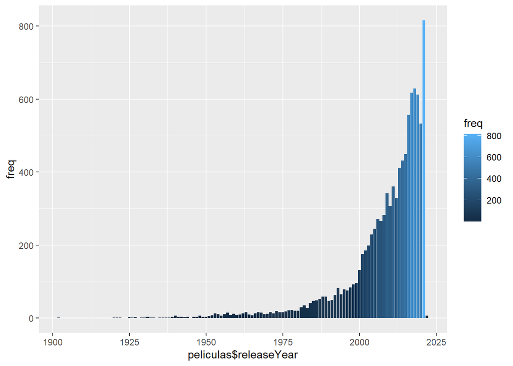

```r
ggplot(yearly, aes(x=`peliculas$releaseYear`, y= freq, fill= freq)) + geom_col(position ="dodge")
```

PREGUNTA #4.8 ¿La cantidad de actores influye en los ingresos de las películas?¿Se han hecho películas con más actores en los últimos años?

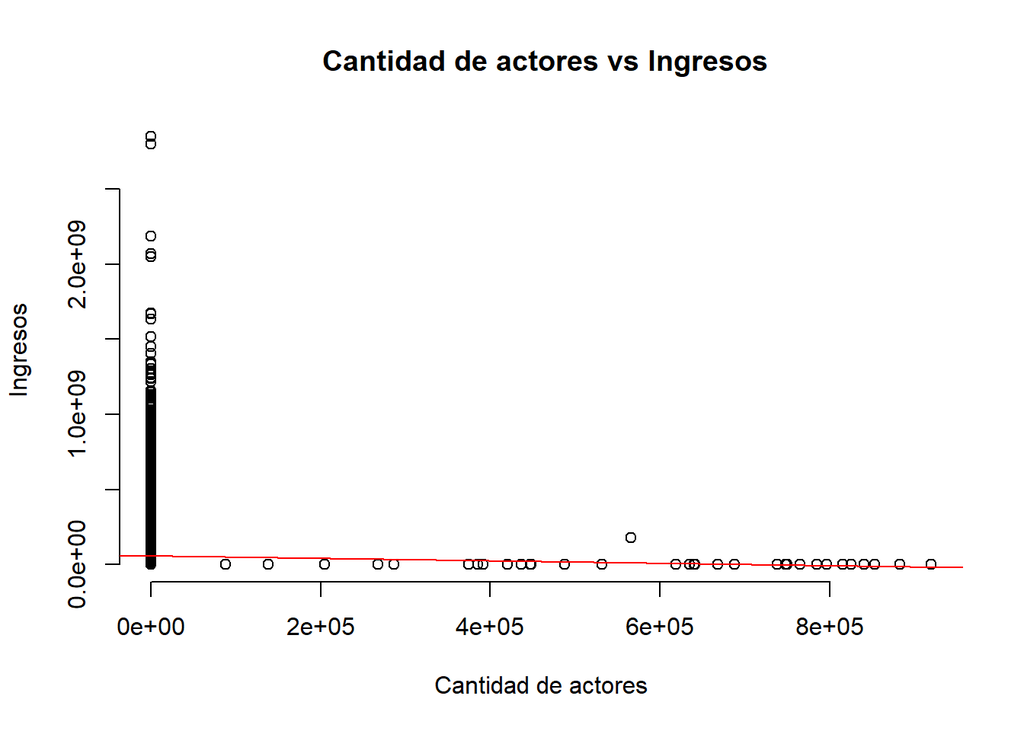

```r
x0 <- peliculas$actorsAmount
y0 <- peliculas$revenue
# Plot with main and axis titles
# Change point shape (pch = 21) and remove frame.
plot(x0, y0, main = " Cantidad de actores vs Ingresos",
     xlab = "Cantidad de actores", ylab = "Ingresos",
     pch = 21, frame = FALSE)
abline(lm(y0 ~ x0, data = peliculas), col = "red")
```

```r
correlation5 <- data.frame(budget=c(peliculas$actorsAmount), revenue=c(peliculas$revenue))
#fit regression model
correlation6 <- lm(actorsAmount~revenue, data=peliculas)
summary(correlation6)
```

```
##
## Call:
## lm(formula = actorsAmount ~ revenue, data = peliculas)
##
## Residuals:
##    Min     1Q Median     3Q    Max
##  -2424  -2410  -2386  -2163 917166
##
## Coefficients:
##               Estimate Std. Error t value Pr(>|t|)
## (Intercept)  2.424e+03  3.978e+02   6.092 1.15e-09 ***
## revenue     -4.863e-06  2.487e-06  -1.956   0.0505 .
## ---
## Signif. codes:  0 '***' 0.001 '**' 0.01 '*' 0.05 '.' 0.1 ' ' 1
##
## Residual standard error: 37190 on 9998 degrees of freedom
## Multiple R-squared:  0.0003824,  Adjusted R-squared:  0.0002824
## F-statistic: 3.825 on 1 and 9998 DF,  p-value: 0.05053
```

```r
actors <- arrange(peliculas, desc(peliculas$actorsAmount))
head (select(actors, "releaseYear", "actorsAmount"),40)
```

```
##    releaseYear actorsAmount
## 1         2021       919590
## 2         2021       882878
## 3         2006       853253
## 4         2006       840964
## 5         2017       825491
## 6         2018       815762
## 7         2008       796822
## 8         2021       784594
## 9         2009       765207
## 10        2020       750209
## 11        2020       748501
## 12        2017       738562
## 13        2004       687920
## 14        2014       668297
```

[output cut: 26 more lines]

PREGUNTA #4.11 ¿Cómo se correlacionan los presupuestos con los ingresos? ¿Los altos presupuestos significan altos ingresos? Haga los gráficos que necesite, histograma, diagrama de dispersión

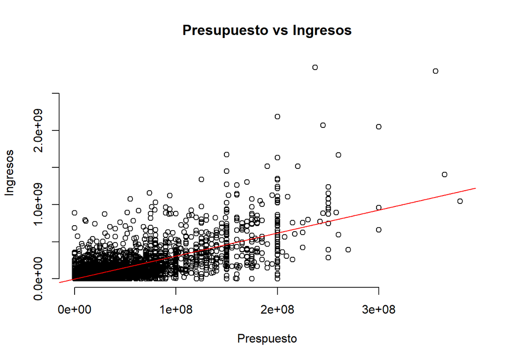

```r
x <- peliculas$budget
y <- peliculas$revenue
# Plot with main and axis titles
# Change point shape (pch = 21) and remove frame.
plot(x, y, main = "Presupuesto vs Ingresos",
     xlab = "Prespuesto", ylab = "Ingresos",
     pch = 21, frame = FALSE)
abline(lm(y ~ x, data = peliculas), col = "red")
```

```r
correlation <- data.frame(budget=c(peliculas$budget), revenue=c(peliculas$revenue))
#fit regression model
correlation2 <- lm(budget~revenue, data=peliculas)
summary(correlation2)
```

```
##
## Call:
## lm(formula = budget ~ revenue, data = peliculas)
##
## Residuals:
##        Min         1Q     Median         3Q        Max
## -299096514   -8028666   -8028666    1971334  191971334
##
## Coefficients:
##              Estimate Std. Error t value Pr(>|t|)
## (Intercept) 8.029e+06  2.558e+05   31.39   <2e-16 ***
## revenue     1.855e-01  1.599e-03  116.00   <2e-16 ***
## ---
## Signif. codes:  0 '***' 0.001 '**' 0.01 '*' 0.05 '.' 0.1 ' ' 1
##
## Residual standard error: 23910000 on 9998 degrees of freedom
## Multiple R-squared:  0.5737, Adjusted R-squared:  0.5737
## F-statistic: 1.346e+04 on 1 and 9998 DF,  p-value: < 2.2e-16
```

PREGUNTA #4.14 ¿Cómo se correlacionan las calificaciones con el éxito comercial?

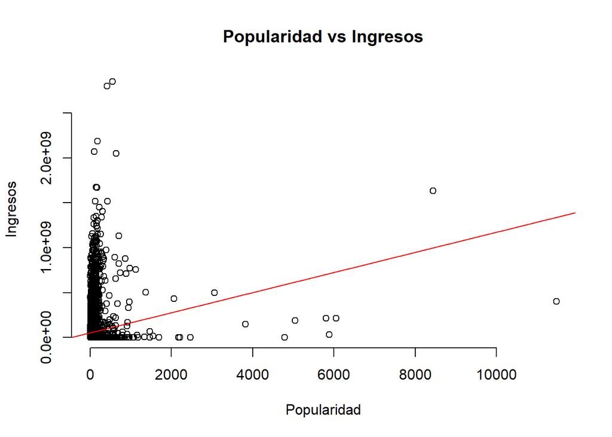

```r
x1 <- peliculas$popularity
y1 <- peliculas$revenue
# Plot with main and axis titles
# Change point shape (pch = 21) and remove frame.
plot(x1, y1, main = "Popularidad vs Ingresos",
     xlab = "Popularidad", ylab = "Ingresos",
     pch = 21, frame = FALSE)
abline(lm(y1 ~ x1, data = peliculas), col = "red")
```

```r
correlation3 <- data.frame(budget=c(peliculas$popularity ), revenue=c(peliculas$revenue))
#fit regression model
correlation4 <- lm(popularity~revenue, data=peliculas)
summary(correlation4)
```

```
##
## Call:
## lm(formula = popularity ~ revenue, data = peliculas)
##
## Residuals:
##     Min      1Q  Median      3Q     Max
##  -419.9   -27.9   -21.8    -7.8 11342.0
##
## Coefficients:
##              Estimate Std. Error t value Pr(>|t|)
## (Intercept) 3.803e+01  2.287e+00   16.63   <2e-16 ***
## revenue     2.355e-07  1.430e-08   16.47   <2e-16 ***
## ---
## Signif. codes:  0 '***' 0.001 '**' 0.01 '*' 0.05 '.' 0.1 ' ' 1
##
## Residual standard error: 213.9 on 9998 degrees of freedom
## Multiple R-squared:  0.02642,    Adjusted R-squared:  0.02632
## F-statistic: 271.3 on 1 and 9998 DF,  p-value: < 2.2e-16
```